# EDA & Data Preprocessing in R

Nurpita Dewi

3/26/2021

## Pendahuluan

Bagain ini merupakan brntuk R Makdwon tentang EDA & Data Preprocessing

### Import Library

```r
if(!require(tidyverse)) install.packages("tidyverse")
if(!require(skimr)) install.packages("skimr")
if(!require(DataExplorer)) install.packages("DataExplorer")
if(!require(visdat)) install.packages("visdat")
```

```r
library(visdat)
library(tidyverse)
library(skimr)
library(DataExplorer)
library(dplyr)
library(ggplot2)
library(tidyr)
library(readr)
library(tibble)
```

### Mengakses Dataset

```r
df<- read.csv("https://raw.githubusercontent.com/AfifNurraihan/Data_Sains_Kelas_Mahir/main/titanic_modify.csv", sep=';',stringsAsFactors = T)
df[0:5]
```

[output not shown]

[output cut: 2109 more lines]

Tampilkan Dta yang akan kita analisis

### Tujuan Analisis Data

Melakukan klasifikasi penumpang yang selamat dan tidak selamat pada kasus tenggelamnya kapal Titanic.

### Memahami dataset

Dataset Titanic dibuat untuk membuat machine learning untuk melakukan klasifikasi biner(Selamat atau Tidak Selamat. Variabel-variabel yang terdapat pada dataset ini adalah sebagai berikut:

1. PassengerId = Nomor Id Penumpang
2. Survived = Keterangan Selamat(0=Tidak, 1=Ya)
3. Pclass = Kelas Tiket (1=Kelas 1, 2=Kelas 2, dst)
4. Name = Nama Penumpang
5. Sex = Jenis kelamin
6. Age = Usia dalam tahun
7. SibSp = Jumlah saudara kandung / pasangan di kapal Titanic
8. Parch = Jumlah orang tua / anak di kapal Titanic
9. Ticket = Nomor Tiket 10.Fare = Harga Tiket 11.Cabin = Nama Kabin 12.Embarked = Pelabuhan Asal (C = Cherbourg, Q = Queenstown, S = Southampton)

##Eksploratory Data Analysis

### Dimensi Data

```r
dim(df)
```

```
## [1] 707  12
```

Artinya kita memiliki data dengan 12 kolom dan 707 baris

### Variabel Pada Dataset

```r
names(df)
```

```
##  [1] "PassengerId" "Survived"    "Pclass"      "Name"        "Sex"
##  [6] "Age"         "SibSp"       "Parch"       "Ticket"      "Fare"
## [11] "Cabin"       "Embarked"
```

```r
str(df)
```

```
## 'data.frame':    707 obs. of  12 variables:
##  $ PassengerId: int  1 2 3 4 5 6 7 8 9 10 ...
##  $ Survived   : int  0 1 1 1 0 0 0 0 1 1 ...
##  $ Pclass     : int  3 1 3 1 3 3 1 3 3 2 ...
##  $ Name       : Factor w/ 707 levels "Abbott, Mrs. Stanton (Rosa Hunt)",..: 86 149 282 221 8 432 401 493 326 449 ...
##  $ Sex        : Factor w/ 2 levels "female","male": 2 1 1 1 2 2 2 2 1 1 ...
##  $ Age        : num  22 38 26 35 35 NA 54 2 27 14 ...
##  $ SibSp      : int  1 1 0 1 0 0 0 3 0 1 ...
##  $ Parch      : int  0 0 0 0 0 0 0 1 2 0 ...
##  $ Ticket     : Factor w/ 563 levels "110152","110413",..: 426 492 554 41 385 227 72 321 281 110 ...
##  $ Fare       : Factor w/ 227 levels "0","1.108.833",..: 158 171 166 133 196 209 130 68 13 101 ...
##  $ Cabin      : Factor w/ 122 levels "","A10","A14",..: 1 70 1 49 1 1 109 1 1 1 ...
##  $ Embarked   : Factor w/ 4 levels "","C","Q","S": 4 2 4 4 4 3 4 4 4 2 ...
```

Kita dapat mengetahui tipe-tipe data masing-masing variabel dan nama-nama variabel dalam dataset.

### Mengecek Missing Data

```r
sapply(df, function(x) sum(is.na(x)))
```

```
## PassengerId    Survived      Pclass        Name         Sex         Age
##           0           0           0           0           0         145
##       SibSp       Parch      Ticket        Fare       Cabin    Embarked
##           0           0           0           0           0           0
```

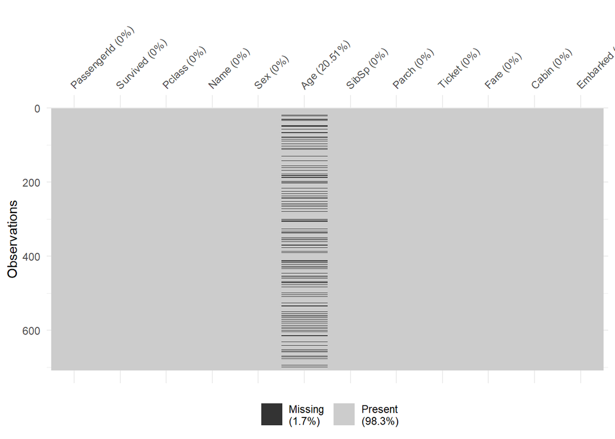

```r
vis_miss(df)
```

### Melihat Korelasi Data

```
## 4 features with more than 20 categories ignored!
## Name: 707 categories
## Ticket: 563 categories
## Fare: 227 categories
## Cabin: 122 categories
```

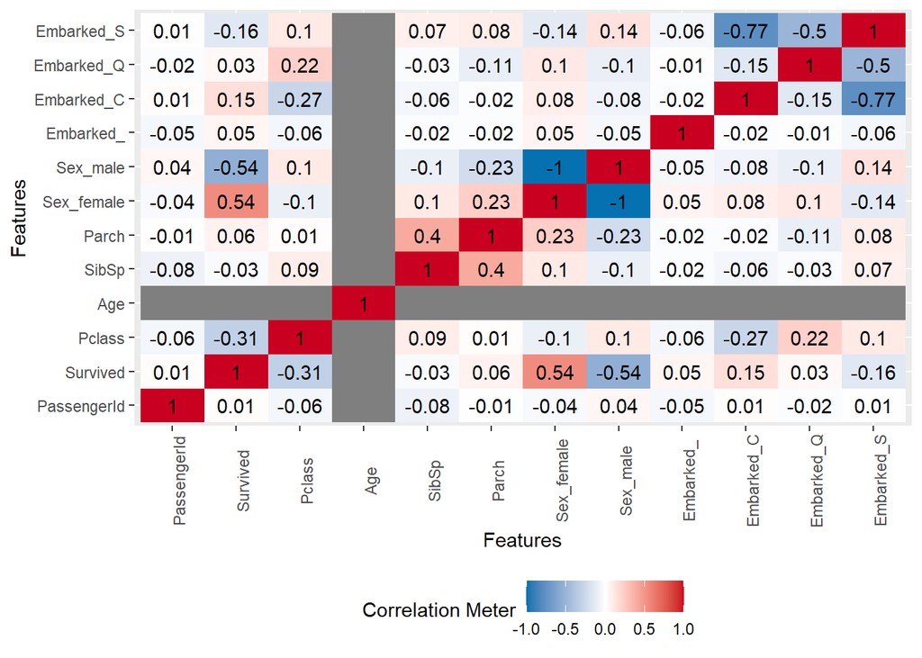

```r
plot_correlation(df)
```

### Melihat Statistik Data

```r
summary(df)
```

```
##   PassengerId       Survived          Pclass
##  Min.   :  1.0   Min.   :0.0000   Min.   :1.000
##  1st Qu.:177.5   1st Qu.:0.0000   1st Qu.:2.000
##  Median :354.0   Median :0.0000   Median :3.000
##  Mean   :354.0   Mean   :0.3876   Mean   :2.308
##  3rd Qu.:530.5   3rd Qu.:1.0000   3rd Qu.:3.000
##  Max.   :707.0   Max.   :1.0000   Max.   :3.000
##
##                                              Name         Sex
##  Abbott, Mrs. Stanton (Rosa Hunt)              :  1   female:254
##  Abelson, Mr. Samuel                           :  1   male  :453
##  Adahl, Mr. Mauritz Nils Martin                :  1
##  Adams, Mr. John                               :  1
##  Ahlin, Mrs. Johan (Johanna Persdotter Larsson):  1
##  Albimona, Mr. Nassef Cassem                   :  1
##  (Other)                                       :701
##       Age            SibSp            Parch                 Ticket
##  Min.   : 0.75   Min.   :0.0000   Min.   :0.0000   CA 2144     :  6
##  1st Qu.:21.00   1st Qu.:0.0000   1st Qu.:0.0000   1601        :  5
##  Median :28.00   Median :0.0000   Median :0.0000   3101295     :  5
##  Mean   :30.03   Mean   :0.5304   Mean   :0.3833   347082      :  5
##  3rd Qu.:39.00   3rd Qu.:1.0000   3rd Qu.:0.0000   347088      :  5
##  Max.   :80.00   Max.   :8.0000   Max.   :6.0000   S.O.C. 14879:  5
##  NA's   :145                                       (Other)     :676
##       Fare             Cabin     Embarked
##  8.05   : 40              :548    :  1
##  13     : 30   C23 C25 C27:  4   C:136
##  78.958 : 29   G6         :  4   Q: 64
##  26     : 27   C22 C26    :  3   S:506
##  7.75   : 27   D          :  3
##  10.5   : 19   F2         :  3
##  (Other):535   (Other)    :142
```

### Pairplot

[figure not shown]

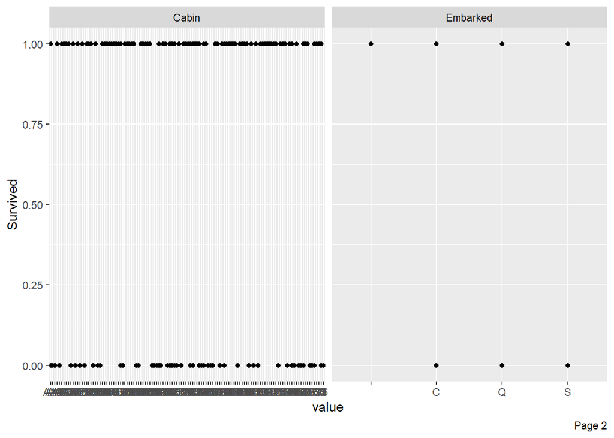

```r
plot_scatterplot(df , by = "Survived")
```

## Data Pre Processing

Data preprocessing ini digunakan guna menyiapkan data untuk diklasifikasi menggunakan metode SVM(Hanya Contoh).

[Note] Ini hanya contoh untuk melakukan pengisian data NaN(Kosong), nama kabin mungkin menjadi penting sehingga tidak segampang itu diganti

### Memperbaiki Missing Value pada Age

```r
df$Age=ifelse(is.na(df$Age),
              ave(df$Age, FUN=function(x)mean(x,na.rm=TRUE)),
              df$Age)
```

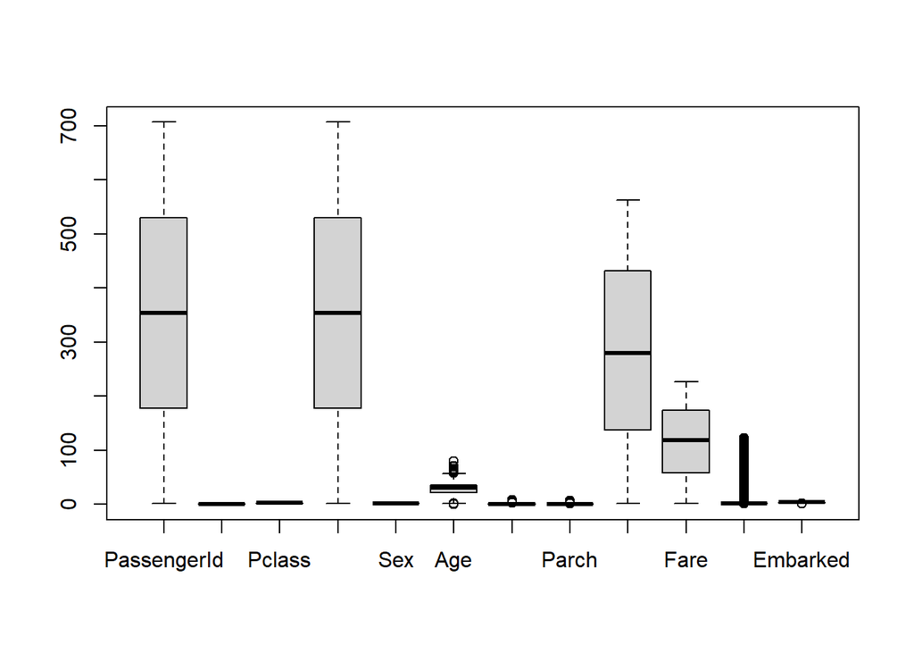

```r
boxplot(df)
```

Maka dari hasil diatas kita telah dapat membersihkan data yang berisi NAN. Untuk tahap selanjutnya belum saya lengkapi dikarenakan terbatas waktu.

Bismillah dilain kesempatan akan saya coba lebih maksimal.

### This is the end of Notebooks

say: Allhamdulillah, panjang banget dah